# Programming and Data Analysis

> Introduction

Yao-Jen Kuo yaojenkuo@ntu.edu.tw from [DATAINPOINT](https://www.datainpoint.com/)

## About programming and data analysis

## What is programming?

> Programming is a sequence of instructions that specifies how to perform a computation. The computation might be something mathematical, such as solving a system of equations, something symbolic, such as searching for and replacing text in a document, or something graphical, like processing an image.

Source: [Think Julia: How to Think Like a Computer Scientist](https://benlauwens.github.io/ThinkJulia.jl/latest/book.html)

## What is data analysis?

> Data analysis is a process of inspecting, cleaning, transforming, and modeling data with the goal of discovering useful information, informing conclusions, and supporting decision-making.

Source: https://en.wikipedia.org/wiki/Data_analysis

## The combination of programming and data analysis: Modern data science

[figure not shown]

Source: [R for Data Science](https://r4ds.had.co.nz/)

## The sarcastic ones

[figure not shown]

Source: https://twitter.com/cdixon/status/428914681911070720/photo/1

## The serious ones

[figure not shown]

Source: http://drewconway.com/

## "Modern data science" is indeed a fancy word.

What is Chandler Bing's job?

> Monica Geller-Bing : I want you to have a job that you love not statistical analysis and data reconfiguration.

> Chandler Bing : I quit, and you learn what I do?

Source: https://www.imdb.com/title/tt0583470/characters/nm0001612

## The Python Trivia

## Topics to be discussed

- Programming with Python.
- Array computing with NumPy.
- Data Wrangling with Pandas.
- Data Visualization with Matplotlib PyPlot.

## We will use Python to tackle everything in the pipeline

[figure not shown]

Source: [R for Data Science](https://r4ds.had.co.nz/)

## Why Python? Why not...

- R?
- Rust?
- Matlab?
- Julia?
- SAS?
- Scala?
- ...etc.

## Let's explore a question in [2022 Kaggle ML & DS Survey](https://www.kaggle.com/c/kaggle-survey-2022)

Q12: What programming languages do you use on a regular basis? (Select all that apply)

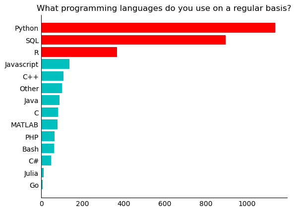

```python
ks.plot_survey_summary(question_index="Q12", n=3)
```

## Let's explore another plot at [Stack Overflow Trends](https://insights.stackoverflow.com/trends?tags=python%2Cr%2Cmatlab%2Cjulia%2Csas%2Cscala%2Crust)

[figure not shown]

Source: Google Search

## The plots speak loud and clear.

## Python is a general-purposed language that is extremely powerful and popular among many applications

- Automation.
- Databases.
- Analytics.
- Graphical user interfaces.
- Machine learning.
- Web frameworks.
- Web scraping.
- ...etc.

## How does Python do all of that?

- Standard libraries.
- Third party libraries.

## What is a standard library?

A standard library refers to any library where the latest version of the code is maintained and hosted by the official organization [Python.org](https://www.python.org/) and comes with the installation of Python.

Source: https://docs.python.org/3.9/library/index.html

## What is a third party library?

A third party library refers to any library where the latest version of the code is not maintained and hosted by neither ourselves nor the official organization [Python.org](https://www.python.org/).

## So which third party library makes Python the go-to choice for data science?

- NumPy
- Pandas
- Matplotlib
- Scikit-Learn
- TensorFlow
- PyTorch
- Hugging Face
- ...etc.

## Setting up a Python Development Environment

## Given Python is a general-purposed programming language, there are variuos ways setting up a Python development environement

## It is a mix-and-match challenge

- The operating system.
- The Python interpreter.
- The Integrated Development Environment.
- The package/environment manager.

## Even among data analysts, everyone has its own favorite flavor

[figure not shown]

Source: https://giphy.com/

## Critical elements of writing/running a Python program

- Text editor.
- Terminal.
- Python interpreter.
- Integrated development environment(IDE).

## We will use the following resources to write/run Python programs

- [Miniconda](https://docs.conda.io/projects/miniconda/en/latest/)
- [Visual Studio Code](https://code.visualstudio.com/download)

## Two Python programs to try

- Hello world!
- The Zen of Python.

## Hello world!

```python
print("Hello world!")
```

```
Hello world!
```

## Zen of Python

Long time Pythoneer Tim Peters) succinctly channels the BDFL's guiding principles for Python's design into 20 aphorisms, only 19 of which have been written down.

```python
import this
```

```
The Zen of Python, by Tim Peters

Beautiful is better than ugly.
Explicit is better than implicit.
Simple is better than complex.
Complex is better than complicated.
Flat is better than nested.
Sparse is better than dense.
Readability counts.
Special cases aren't special enough to break the rules.
Although practicality beats purity.
Errors should never pass silently.
Unless explicitly silenced.
In the face of ambiguity, refuse the temptation to guess.
There should be one-- and preferably only one --obvious way to do it.
Although that way may not be obvious at first unless you're Dutch.
Now is better than never.
Although never is often better than *right* now.
If the implementation is hard to explain, it's a bad idea.
If the implementation is easy to explain, it may be a good idea.
Namespaces are one honking great idea -- let's do more of those!
```